# Exploratory Data Analysis (EDA) on Instacart Orders Dataset

## Introduction

This project aims to analyze customer shopping behavior using the Instacart dataset. The dataset contains transactional data, including details about orders, products, aisles, and departments. Through **data cleaning, preprocessing, and visualization**, we uncover insights about purchasing patterns, reorder behaviors, and shopping trends.

## Project Objectives

1. **Data Cleaning & Preprocessing**
   - Handle missing values, duplicate entries, and ensure data integrity.
2. **Exploratory Data Analysis (EDA)**
   - Identify trends in shopping behavior (e.g., peak shopping hours, most purchased items).
   - Analyze reorder patterns and customer purchasing habits.
3. **Business Insights**
   - Provide actionable insights that can help Instacart optimize inventory, marketing, and customer retention strategies.

## Dataset Overview

- `orders.csv`: Contains details about each customer order (order ID, user ID, time of order, etc.).
- `products.csv`: Includes product information (product ID, name, aisle, department).
- `aisles.csv`: Maps each product to its respective aisle.
- `departments.csv`: Categorizes products into broader department groups.
- `order_products`: Link products to orders and indicate reorder status.

This EDA project will utilize **Python, Pandas, and Matplotlib** to extract meaningful patterns from the data. The findings will help in understanding customer behavior, optimizing operations, and improving user experience.

```python
import pandas as pd
```

```python
#reading the orders Data
orders = pd.read_csv('C:/Users/kwame/Downloads/instacart_orders.csv', sep=';')
```

```python
orders.head()
```

|  | order_id | user_id | order_number | order_dow | order_hour_of_day | days_since_prior_order |
| --- | --- | --- | --- | --- | --- | --- |
| 0 | 1515936 | 183418 | 11 | 6 | 13 | 30.0 |
| 1 | 1690866 | 163593 | 5 | 5 | 12 | 9.0 |
| 2 | 1454967 | 39980 | 4 | 5 | 19 | 2.0 |
| 3 | 1768857 | 82516 | 56 | 0 | 20 | 10.0 |
| 4 | 3007858 | 196724 | 2 | 4 | 12 | 17.0 |

```python
#reading the orders_products data
order_products = pd.read_csv('C:/Users/kwame/Downloads/order_products.csv',sep=';')
```

```python
order_products.head()
```

|  | order_id | product_id | add_to_cart_order | reordered |
| --- | --- | --- | --- | --- |
| 0 | 2141543 | 11440 | 17.0 | 0 |
| 1 | 567889 | 1560 | 1.0 | 1 |
| 2 | 2261212 | 26683 | 1.0 | 1 |
| 3 | 491251 | 8670 | 35.0 | 1 |
| 4 | 2571142 | 1940 | 5.0 | 1 |

```python
products = pd.read_csv('C:/Users/kwame/Downloads/products.csv',sep=';')
```

```python
products.head()
```

|  | product_id | product_name | aisle_id | department_id |
| --- | --- | --- | --- | --- |
| 0 | 1 | Chocolate Sandwich Cookies | 61 | 19 |
| 1 | 2 | All-Seasons Salt | 104 | 13 |
| 2 | 3 | Robust Golden Unsweetened Oolong Tea | 94 | 7 |
| 3 | 4 | Smart Ones Classic Favorites Mini Rigatoni Wit... | 38 | 1 |
| 4 | 5 | Green Chile Anytime Sauce | 5 | 13 |

```python
aisles = pd.read_csv('C:/Users/kwame/Downloads/aisles.csv',sep=';')
```

```python
aisles.head()
```

|  | aisle_id | aisle |
| --- | --- | --- |
| 0 | 1 | prepared soups salads |
| 1 | 2 | specialty cheeses |
| 2 | 3 | energy granola bars |
| 3 | 4 | instant foods |
| 4 | 5 | marinades meat preparation |

```python
departments = pd.read_csv('C:/Users/kwame/Downloads/departments.csv',sep=';')
```

```python
departments.head()
```

|  | department_id | department |
| --- | --- | --- |
| 0 | 1 | frozen |
| 1 | 2 | other |
| 2 | 3 | bakery |
| 3 | 4 | produce |
| 4 | 5 | alcohol |

## Find and remove duplicate values in the orders dataframe

## Reasons for this process

- **If duplicates exist, they could indicate errors in data collection or processing**.
- **Duplicates could lead to double-counting orders in any subsequent analysis, such as customer purchase patterns and reorder rates.**

```python
# Check for duplicated in orders dataframe
duplicate_orders = orders[orders.duplicated()]
print(f"Number of duplicate rows in orders: {duplicate_orders.shape[0]}")
```

```
Number of duplicate rows in orders: 15
```

```python
# Check for all orders placed Wednesday at 2:00 AM
wednesday_2am_orders = orders[(orders['order_dow'] == 3) & (orders['order_hour_of_day'] == 2)]

print(f"Number of orders placed on Wednesday at 2:00 AM: {wednesday_2am_orders.shape[0]}")
print(wednesday_2am_orders.head())
```

```
Number of orders placed on Wednesday at 2:00 AM: 121
       order_id  user_id  order_number  order_dow  order_hour_of_day  \
4838    2766110   162084            41          3                  2
5156    2190225   138285            18          3                  2
15506    553049    58599            13          3                  2
18420    382357   120200            19          3                  2
24691    690242    77357             2          3                  2

       days_since_prior_order
4838                     16.0
5156                     11.0
15506                     7.0
18420                    11.0
24691                     9.0
```

```python
# Remove duplicate orders

# Check for duplicate order IDs
duplicate_orders = orders[orders.duplicated(subset=['order_id'], keep=False)]
print(f"Number of duplicate orders: {duplicate_orders.shape[0]}")

# Remove duplicate orders while keeping the first occurrence
orders_cleaned = orders.drop_duplicates(subset=['order_id'], keep='first')

# Verify duplicates are removed
print(f"Number of unique orders after cleaning: {orders_cleaned.shape[0]}")
```

```
Number of duplicate orders: 30
Number of unique orders after cleaning: 478952
```

```python
# Double check for duplicate order IDs only
duplicate_rows = orders_cleaned[orders_cleaned.duplicated(keep=False)]

print(f"Number of fully duplicate rows: {duplicate_rows.shape[0]}")
```

```
Number of fully duplicate rows: 0
```

## Find and remove duplicate values in the order_products dataframe

```python
# Check for fullly duplicate rows

duplicate_rows = order_products[order_products.duplicated(keep=False)]

print(f"Number of fully duplicate rows: {duplicate_rows.shape[0]}")
```

```
Number of fully duplicate rows: 0
```

```python
# Check for duplicate order_id and product_id pairs
duplicate_order_product_pairs = order_products[order_products.duplicated(subset=['order_id', 'product_id'], keep=False)]
print(f"Number of duplicate order-product pairs: {duplicate_order_product_pairs.shape[0]}")

# Check for any duplicate rows with slight variations (e.g., whitespace issues)
stripped_order_products = order_products.map(lambda x: x.strip() if isinstance(x, str) else x)
duplicate_rows_stripped = stripped_order_products[stripped_order_products.duplicated(keep=False)]
print(f"Number of duplicate rows after stripping whitespace: {duplicate_rows_stripped.shape[0]}")

# If any tricky duplicates are found, we can drop them
order_products_cleaned = stripped_order_products.drop_duplicates()
print(f"Number of rows after removing tricky duplicates: {order_products_cleaned.shape[0]}")
```

```
Number of duplicate order-product pairs: 0
Number of duplicate rows after stripping whitespace: 0
Number of rows after removing tricky duplicates: 4545007
```

## Find and remove duplicate values in the products dataframe

## Reasons for this processes

- **Check for duplicate product IDs**
- **Each product should be uniquely identified by 'product_id'.**
- **If duplicate product IDs exist, it could mean duplicate product entries in the catalog,leading to data inconsistencies and potential errors in analysis.**

```python
# Check for fully duplicate rows
duplicate_products = products[products.duplicated(keep=False)]

print(f"Number of fully duplicate rows in Products DataFrame: {duplicate_products.shape[0]}")
```

```
Number of fully duplicate rows in Products DataFrame: 0
```

```python
 #Check for just duplicate product IDs
duplicate_product_ids = products[products.duplicated(subset=['product_id'], keep=False)]

print(f"Number of duplicate product IDs: {duplicate_product_ids.shape[0]}")
```

```
Number of duplicate product IDs: 0
```

```python
# Check for just duplicate product names (convert names to lowercase to compare better)

# Convert product names to lowercase and check for duplicates
duplicate_product_names = products[products.duplicated(subset=['product_name'], keep=False)]

print(f"Number of duplicate product names (case-sensitive): {duplicate_product_names.shape[0]}")

# Convert product names to lowercase for better comparison
products['product_name_lower'] = products['product_name'].str.lower()

# Check for duplicate product names (case-insensitive)
duplicate_product_names_lower = products[products.duplicated(subset=['product_name_lower'], keep=False)]

print(f"Number of duplicate product names (case-insensitive): {duplicate_product_names_lower.shape[0]}")
```

```
Number of duplicate product names (case-sensitive): 1258
Number of duplicate product names (case-insensitive): 1465
```

```python
# Check for duplicate product names that aren't missing
# Drop missing values in 'product_name'
non_missing_products = products.dropna(subset=['product_name']).copy()

# Convert product names to lowercase for better comparison
non_missing_products.loc[:, 'product_name_lower'] = non_missing_products['product_name'].str.lower()

# Find duplicate product names (ignoring case)
duplicate_product_names = non_missing_products[non_missing_products.duplicated(subset=['product_name_lower'], keep=False)]

print(f"Number of duplicate product names (excluding missing values): {duplicate_product_names.shape[0]}")
```

```
Number of duplicate product names (excluding missing values): 207
```

## Find and remove duplicate values in the aisle dataframe

## Reasons for this process

- **Check for duplicate aisle IDs**
- **Each aisle should be uniquely identified by aisle_id.**
- **Duplicates could indicate data mismanagement or duplicate aisle names.**

```python
# Check for fully duplicate rows in the aisles dataframe
duplicate_aisles = aisles[aisles.duplicated(keep=False)]

# Print the number of fully duplicate rows
print(f"Number of fully duplicate rows: {duplicate_aisles.shape[0]}")

# Display duplicate rows if any
duplicate_aisles
```

```
Number of fully duplicate rows: 0
```

|  | aisle_id | aisle |
| --- | --- | --- |

```python
# Remove fully duplicate rows from the aisles dataframe
aisles = aisles.drop_duplicates()

# Print confirmation
print(f"Number of rows after removing duplicates: {aisles.shape[0]}")
```

```
Number of rows after removing duplicates: 134
```

## Find and remove duplicate values in the department dataframe

## Reasons for this process

- **Check for duplicate department IDs**
- **Each department should be uniquely identified by department_id.**
- **Duplicates could indicate data integrity issues and inconsistencies in department labeling.**

```python
# Check for fully duplicate rows in the department dataframe
duplicate_departments = departments[departments.duplicated(keep=False)]

# Print the number of fully duplicate rows
print(f"Number of fully duplicate rows: {duplicate_departments.shape[0]}")

# Display duplicate rows if any
duplicate_departments
```

```
Number of fully duplicate rows: 0
```

|  | department_id | department |
| --- | --- | --- |

```python
# Remove fully duplicate rows from the department dataframe
departments = departments.drop_duplicates()

# Print confirmation
print(f"Number of rows after removing duplicates: {departments.shape[0]}")
```

```
Number of rows after removing duplicates: 21
```

## Find and remove missing values

## products data frame

```python
# Check for missing values in the products DataFrame
missing_values = products.isnull().sum()
print("Missing values per column:\n", missing_values)

# Drop rows where product_name is missing and create a copy to avoid SettingWithCopyWarning
products_cleaned = products.dropna(subset=['product_name']).copy()

# Fill missing aisle_id and department_id safely
products_cleaned.loc[:, ['aisle_id', 'department_id']] = products_cleaned[['aisle_id', 'department_id']].fillna(-1)

# Check if missing values are removed
print("Missing values after cleaning:\n", products_cleaned.isnull().sum())
```

```
Missing values per column:
 product_id               0
product_name          1258
aisle_id                 0
department_id            0
product_name_lower    1258
dtype: int64
Missing values after cleaning:
 product_id            0
product_name          0
aisle_id              0
department_id         0
product_name_lower    0
dtype: int64
```

```python
# Are all of the missing product names associated with aisle ID 100?
missing_products = products[products['product_name'].isna()]  # Filter missing product names

# Check if all missing product names have aisle_id 100
all_aisle_100 = missing_products['aisle_id'].eq(100).all()

print(f"Are all missing product names associated with aisle ID 100? {all_aisle_100}")
```

```
Are all missing product names associated with aisle ID 100? True
```

```python
# Are all of the missing product names associated with department ID 21?

# Check if all missing product names have department_id 21
all_department_21 = missing_products['department_id'].eq(21).all()

print(f"Are all missing product names associated with department ID 21? {all_department_21}")
```

```
Are all missing product names associated with department ID 21? True
```

```python
# What is this ailse and department?
# Get the aisle name for ID 100
aisle_name = aisles.loc[aisles['aisle_id'] == 100, 'aisle'].values[0]

# Get the department name for ID 21
department_name = departments.loc[departments['department_id'] == 21, 'department'].values[0]

print(f"Aisle ID 100 corresponds to: {aisle_name}")
print(f"Department ID 21 corresponds to: {department_name}")
```

```
Aisle ID 100 corresponds to: missing
Department ID 21 corresponds to: missing
```

```python
# Fill missing product names with 'Unknown'
# Fill missing product names with 'Unknown'
products['product_name'].fillna('Unknown', inplace=True)

# Verify that there are no missing values left
missing_count = products['product_name'].isna().sum()
print(f"Number of missing product names after filling: {missing_count}")
```

```
Number of missing product names after filling: 0
```

## orders data frame

```python
# Check for missing values in the orders DataFrame
missing_values = orders.isnull().sum()
print("Missing values in each column:\n", missing_values)
```

```
Missing values in each column:
 order_id                      0
user_id                       0
order_number                  0
order_dow                     0
order_hour_of_day             0
days_since_prior_order    28819
dtype: int64
```

```python
# Are there any missing values where it's not a customer's first order?
# Check for missing values in 'days_since_prior_order'
missing_orders = orders[orders['days_since_prior_order'].isnull()]
print(f"Total missing values in 'days_since_prior_order': {missing_orders.shape[0]}")


# Check if all missing values belong to first orders (order_number == 1)
non_first_order_missing = missing_orders[missing_orders['order_number'] != 1]

# Display the results
if non_first_order_missing.shape[0] == 0:
    print("✅ All missing values in 'days_since_prior_order' belong to first orders.")
else:
    print(f"⚠️ There are {non_first_order_missing.shape[0]} missing values in non-first orders.")
    print(non_first_order_missing)
```

```
Total missing values in 'days_since_prior_order': 28819
✅ All missing values in 'days_since_prior_order' belong to first orders.
```

## order_products data frame

```python
# Check for missing values in order_products dataframe
missing_values = order_products.isnull().sum()
print("Missing values in order_products dataframe:\n", missing_values)
```

```
Missing values in order_products dataframe:
 order_id               0
product_id             0
add_to_cart_order    836
reordered              0
dtype: int64
```

```python
# What are the min and max values in this column?

min_value = order_products['add_to_cart_order'].min()
max_value = order_products['add_to_cart_order'].max()

print(f"Minimum add_to_cart_order: {min_value}")
print(f"Maximum add_to_cart_order: {max_value}")
```

```
Minimum add_to_cart_order: 1.0
Maximum add_to_cart_order: 64.0
```

```python
# Save all order IDs with at least one missing value in 'add_to_cart_order'

# Find order_ids with missing values in 'add_to_cart_order'
orders_with_missing = order_products[order_products['add_to_cart_order'].isna()]['order_id'].unique()

# Save to a CSV file
pd.DataFrame(orders_with_missing, columns=['order_id']).to_csv("orders_with_missing_add_to_cart_order.csv", index=False)

print(f"Saved {len(orders_with_missing)} orders with missing 'add_to_cart_order' values.")
```

```
Saved 70 orders with missing 'add_to_cart_order' values.
```

```python
# Do all orders with missing values have more than 64 products?

# Count the number of products per order
order_counts = order_products.groupby('order_id')['product_id'].count()

# Get orders with missing 'add_to_cart_order' values
orders_with_missing = order_products[order_products['add_to_cart_order'].isna()]['order_id'].unique()

# Check if all these orders have more than 64 products
all_above_64 = (order_counts[orders_with_missing] > 64).all()

print(f"Do all orders with missing values have more than 64 products? {all_above_64}")
```

```
Do all orders with missing values have more than 64 products? True
```

```python
# Replace missing values with 999 and convert column to integer type

# Convert to nullable integer type (allows missing values to remain as NaN)
order_products['add_to_cart_order'] = order_products['add_to_cart_order'].astype('Int64')

# Verify changes
print(order_products['add_to_cart_order'].dtype)  # Should print 'Int64'
print(order_products['add_to_cart_order'].isna().sum())  # This will show the count of missing values
```

```
Int64
836
```

## Verify that the 'order_hour_of_day' and 'order_dow' values in the orders tables are sensible (i.e. 'order_hour_of_day' ranges from 0 to 23 and 'order_dow' ranges from 0 to 6)

```python
# Check the range of order_hour_of_day
min_hour = orders['order_hour_of_day'].min()
max_hour = orders['order_hour_of_day'].max()

# Check the range of order_dow
min_dow = orders['order_dow'].min()
max_dow = orders['order_dow'].max()

# Print results
print(f"order_hour_of_day ranges from {min_hour} to {max_hour}")
print(f"order_dow ranges from {min_dow} to {max_dow}")

# Check for unexpected values
unexpected_hours = orders[~orders['order_hour_of_day'].between(0, 23)]
unexpected_dow = orders[~orders['order_dow'].between(0, 6)]

# Display any problematic rows
if not unexpected_hours.empty:
    print("Unexpected values found in order_hour_of_day:")
    print(unexpected_hours)

if not unexpected_dow.empty:
    print("Unexpected values found in order_dow:")
    print(unexpected_dow)
```

```
order_hour_of_day ranges from 0 to 23
order_dow ranges from 0 to 6
```

## What time of day do people shop for groceries?

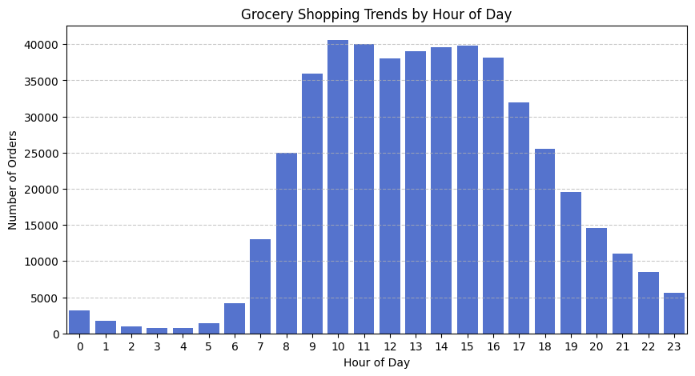

```python
import matplotlib.pyplot as plt
import seaborn as sns

# Count orders by hour of the day
order_hour_counts = orders['order_hour_of_day'].value_counts().sort_index()

# Plot the distribution
plt.figure(figsize=(10, 5))
sns.barplot(x=order_hour_counts.index, y=order_hour_counts.values, color="royalblue")
plt.xlabel("Hour of Day")
plt.ylabel("Number of Orders")
plt.title("Grocery Shopping Trends by Hour of Day")
plt.xticks(range(0, 24))
plt.grid(axis='y', linestyle='--', alpha=0.7)
plt.show()
```

## Business Implications:

- Retailers can schedule staff shifts to match peak hours and ensure adequate stock.
- Promotions and targeted ads can be more effective during high-traffic hours (10 AM–4 PM).
- Midnight and early morning orders could indicate demand for 24/7 delivery options.

## What day of the week do people shop for groceries?

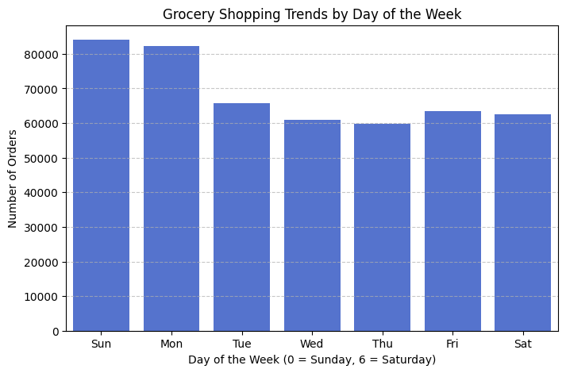

```python
# Count orders by day of the week
order_dow_counts = orders['order_dow'].value_counts().sort_index()

# Plot the distribution
plt.figure(figsize=(8, 5))
sns.barplot(x=order_dow_counts.index, y=order_dow_counts.values, color="royalblue")
plt.xlabel("Day of the Week (0 = Sunday, 6 = Saturday)")
plt.ylabel("Number of Orders")
plt.title("Grocery Shopping Trends by Day of the Week")
plt.xticks(range(0, 7), ["Sun", "Mon", "Tue", "Wed", "Thu", "Fri", "Sat"])
plt.grid(axis='y', linestyle='--', alpha=0.7)
plt.show()
```

## How long do people wait until placing another order?

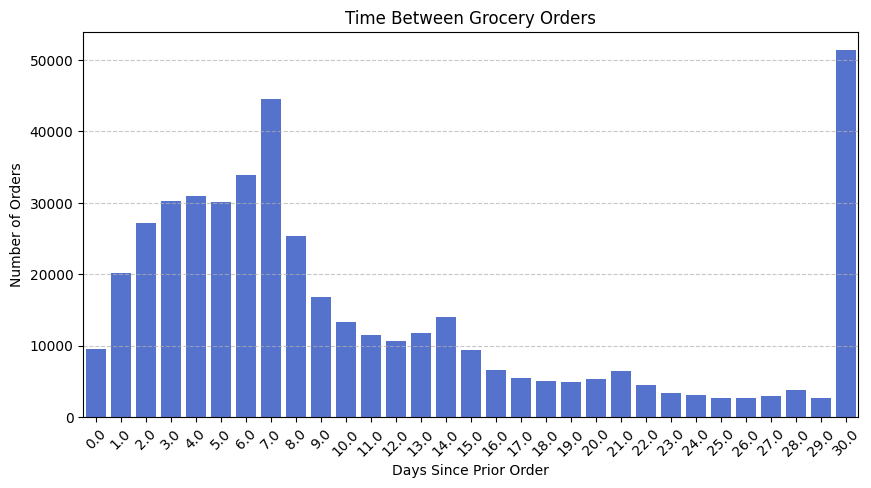

```python
# Count occurrences of each unique value in 'days_since_prior_order'
days_counts = orders['days_since_prior_order'].value_counts().sort_index()

# Plot the distribution
plt.figure(figsize=(10, 5))
sns.barplot(x=days_counts.index, y=days_counts.values, color="royalblue")
plt.xlabel("Days Since Prior Order")
plt.ylabel("Number of Orders")
plt.title("Time Between Grocery Orders")
plt.xticks(rotation=45)
plt.grid(axis='y', linestyle='--', alpha=0.7)
plt.show()
```

## Insights from Time Between Grocery Orders

The distribution of days since the prior order shows clear peaks at 7, 14, 21, and 30 days, suggesting that many customers follow a weekly or monthly shopping cycle. A significant portion of customers place orders exactly one week apart, likely due to weekly meal planning or grocery restocking habits. There is another noticeable peak around 30 days, which could indicate monthly bulk shoppers or customers who make large purchases less frequently.

## Business Implications

Targeted Promotions: Retailers can offer weekly or monthly reminders and promotions to encourage repeat purchases. Subscription Services: Grocery stores could introduce weekly or monthly subscription-based grocery delivery plans to match customer buying patterns. Inventory Management: Stores can optimize inventory and restocking schedules to align with customer shopping habits, ensuring key products are available at peak times.

## Is there a difference in 'order_hour_of_day' distributions on Wednesdays and Saturdays? Plot the histograms for both days and describe the differences that you see.

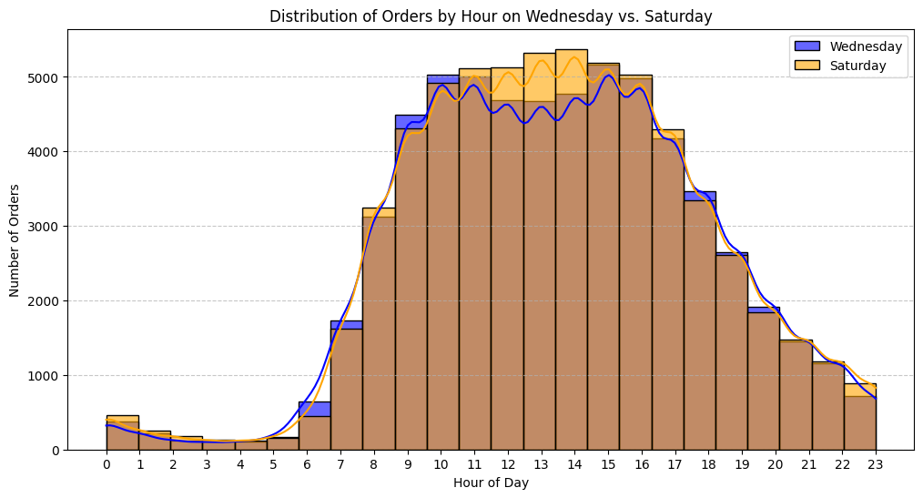

```python
import matplotlib.pyplot as plt
import seaborn as sns

# Filter data for Wednesday (3) and Saturday (6)
wednesday_orders = orders[orders['order_dow'] == 3]['order_hour_of_day']
saturday_orders = orders[orders['order_dow'] == 6]['order_hour_of_day']

# Plot histograms
plt.figure(figsize=(12, 6))
sns.histplot(wednesday_orders, bins=24, color='blue', label='Wednesday', kde=True, alpha=0.6)
sns.histplot(saturday_orders, bins=24, color='orange', label='Saturday', kde=True, alpha=0.6)

# Labels and title
plt.xlabel("Hour of Day")
plt.ylabel("Number of Orders")
plt.title("Distribution of Orders by Hour on Wednesday vs. Saturday")
plt.legend()
plt.xticks(range(0, 24))
plt.grid(axis='y', linestyle='--', alpha=0.7)

# Show plot
plt.show()
```

## Business Implications

### What's the distribution for the number of orders per customer?

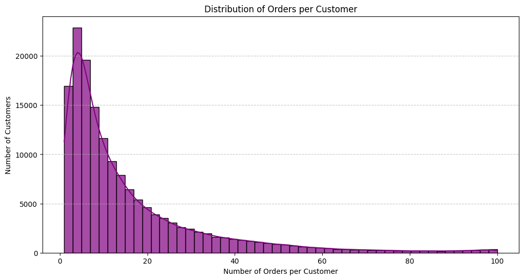

```python
import matplotlib.pyplot as plt
import seaborn as sns

# Count number of orders per customer
customer_order_counts = orders.groupby('user_id')['order_number'].max()

# Plot the distribution
plt.figure(figsize=(12, 6))
sns.histplot(customer_order_counts, bins=50, kde=True, color="purple", alpha=0.7)

# Labels and title
plt.xlabel("Number of Orders per Customer")
plt.ylabel("Number of Customers")
plt.title("Distribution of Orders per Customer")
plt.grid(axis='y', linestyle='--', alpha=0.7)

# Show plot
plt.show()
```

## Insights from the Distribution of Orders per Customer

Customer Ordering Behavior: The majority of customers place only a few orders, indicating that many may be new users or infrequent shoppers. A smaller group of loyal customers places a high number of orders, demonstrating repeat purchasing behavior over time. The distribution likely follows a right-skewed pattern, with most users on the lower end and a few heavy shoppers on the higher end.

## Business Implications

Customer Retention: Implement loyalty programs or personalized promotions to encourage repeat purchases among less frequent shoppers. High-Value Customers: Identify and reward loyal customers with exclusive deals, discounts, or subscription-based perks. Marketing Strategies: Segment customers based on their order frequency and tailor marketing campaigns to engage both occasional and frequent shoppers.

## What are the top 20 popular products (display their id and name)?

```python
# Count the number of times each product appears in orders
top_products = order_products['product_id'].value_counts().reset_index()
top_products.columns = ['product_id', 'order_count']

# Merge with product names
top_products = top_products.merge(products[['product_id', 'product_name']], on='product_id', how='left')

# Display the top 20 products
top_20_products = top_products.head(20)
print(top_20_products)
```

```
    product_id  order_count              product_name
0        24852        66050                    Banana
1        13176        53297    Bag of Organic Bananas
2        21137        37039      Organic Strawberries
3        21903        33971      Organic Baby Spinach
4        47209        29773      Organic Hass Avocado
5        47766        24689           Organic Avocado
6        47626        21495               Large Lemon
7        16797        20018              Strawberries
8        26209        19690                     Limes
9        27845        19600        Organic Whole Milk
10       27966        19197       Organic Raspberries
11       22935        15898      Organic Yellow Onion
12       24964        15292            Organic Garlic
13       45007        14584          Organic Zucchini
14       39275        13879       Organic Blueberries
15       49683        13675            Cucumber Kirby
16       28204        12544        Organic Fuji Apple
17        5876        12232             Organic Lemon
18        8277        11993  Apple Honeycrisp Organic
19       40706        11781    Organic Grape Tomatoes
```

## How many items do people typically buy in one order? What does the distribution look like?

```python
# Count the number of products per order
order_sizes = order_products.groupby('order_id')['product_id'].count()

# Summary statistics
print(order_sizes.describe())
```

```
count    450046.000000
mean         10.098983
std           7.540206
min           1.000000
25%           5.000000
50%           8.000000
75%          14.000000
max         127.000000
Name: product_id, dtype: float64
```

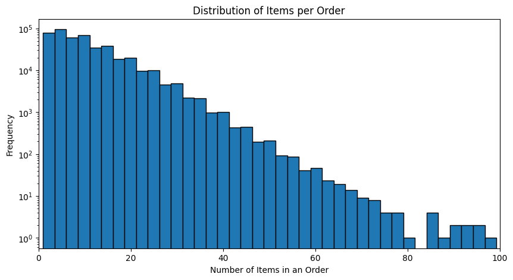

```python
# Plot histogram
plt.figure(figsize=(10, 5))
plt.hist(order_sizes, bins=50, edgecolor='black')
plt.xlabel("Number of Items in an Order")
plt.ylabel("Frequency")
plt.title("Distribution of Items per Order")
plt.xlim(0, 100)  # Limit x-axis for readability
plt.yscale('log')  # Log scale for better visualization of distribution
plt.show()
```

## Insights from the Distribution of Items per Order

Order Size Variability: Most grocery orders contain a moderate number of items, with a declining frequency as order size increases. A long tail is observed, where some customers place very large orders, though they are relatively rare. The logarithmic scale highlights that small to mid-sized orders are the most common, while bulk shopping occurs less frequently.

## Business Implications

Cart Optimization: Encourage larger basket sizes through bundling offers, discounts on bulk purchases, or free shipping thresholds. Stocking Strategy: Retailers can adjust inventory planning by focusing on frequently purchased item quantities to reduce stockouts. Logistics & Delivery: Understanding order sizes can help optimize packaging, delivery schedules, and fulfillment strategies for online grocery services.

## What are the top 20 items that are reordered most frequently (display their names and product IDs)?

```python
# Count reorders for each product_id
reorder_counts = order_products[order_products['reordered'] == 1] \
    .groupby('product_id')['reordered'].count() \
    .reset_index() \
    .rename(columns={'reordered': 'reorder_count'})

# Merge with products dataframe to get product names
top_reordered_products = reorder_counts.merge(products, on='product_id')

# Sort by reorder count and select top 20
top_20_reordered = top_reordered_products.sort_values(by='reorder_count', ascending=False).head(20)

# Display results
print(top_20_reordered[['product_id', 'product_name', 'reorder_count']])
```

```
       product_id              product_name  reorder_count
18104       24852                    Banana          55763
9528        13176    Bag of Organic Bananas          44450
15368       21137      Organic Strawberries          28639
15936       21903      Organic Baby Spinach          26233
34407       47209      Organic Hass Avocado          23629
34828       47766           Organic Avocado          18743
20285       27845        Organic Whole Milk          16251
34725       47626               Large Lemon          15044
20375       27966       Organic Raspberries          14748
12193       16797              Strawberries          13945
19088       26209                     Limes          13327
16700       22935      Organic Yellow Onion          11145
18186       24964            Organic Garlic          10411
32792       45007          Organic Zucchini          10076
36219       49683            Cucumber Kirby           9538
20543       28204        Organic Fuji Apple           8989
5978         8277  Apple Honeycrisp Organic           8836
28607       39275       Organic Blueberries           8799
4267         5876             Organic Lemon           8412
35905       49235       Organic Half & Half           8389
```

## For each product, what proportion of its orders are reorders?

```python
# Total orders per product
total_orders = order_products.groupby('product_id').size().reset_index(name='total_orders')

# Total reorders per product
reorder_counts = order_products[order_products['reordered'] == 1] \
    .groupby('product_id').size().reset_index(name='total_reorders')

# Merge both datasets on product_id
reorder_proportion = total_orders.merge(reorder_counts, on='product_id', how='left')

# Fill missing values (some products may have zero reorders)
reorder_proportion['total_reorders'] = reorder_proportion['total_reorders'].fillna(0)

# Compute reorder proportion
reorder_proportion['reorder_proportion'] = reorder_proportion['total_reorders'] / reorder_proportion['total_orders']

# Merge with product names
reorder_proportion = reorder_proportion.merge(products[['product_id', 'product_name']], on='product_id')

# Display results sorted by reorder proportion
print(reorder_proportion[['product_id', 'product_name', 'reorder_proportion']].sort_values(by='reorder_proportion', ascending=False))
```

```
       product_id                                   product_name  \
28108       30644                           Organic French Roast
7340         8054                     Bissli Smokey Wheat Snacks
28114       30650                Mushroom Lover's Veggie Burgers
41002       44747                    Frozen Organic Blackberries
40998       44743                                 Real Zero Cola
...           ...                                            ...
17561       19170     Cheddar Cheese With Jalapeño Peppers Block
17543       19150                    Plum Smart 100% Juice Blend
28100       30634  Riserva Porcini Mushrooms & White Truffle Oil
44             51              Sa Extra Hold Mousse Hair Styling
22013       23994                                        Unknown

       reorder_proportion
28108                 1.0
7340                  1.0
28114                 1.0
41002                 1.0
40998                 1.0
...                   ...
17561                 0.0
17543                 0.0
28100                 0.0
44                    0.0
22013                 0.0

[45573 rows x 3 columns]
```

## For each customer, what proportion of their products ordered are reorders?

```python
# Merge orders with order_products to get user_id
orders_merged = order_products.merge(orders[['order_id', 'user_id']], on='order_id')

# Total products ordered per customer
total_products_per_user = orders_merged.groupby('user_id').size().reset_index(name='total_products')

# Total reorders per customer
reordered_products_per_user = orders_merged[orders_merged['reordered'] == 1] \
    .groupby('user_id').size().reset_index(name='total_reorders')

# Merge both datasets
reorder_proportion_per_user = total_products_per_user.merge(reordered_products_per_user, on='user_id', how='left')

# Fill missing values (some users may have zero reorders)
reorder_proportion_per_user['total_reorders'] = reorder_proportion_per_user['total_reorders'].fillna(0)

# Compute reorder proportion
reorder_proportion_per_user['reorder_proportion'] = reorder_proportion_per_user['total_reorders'] / reorder_proportion_per_user['total_products']

# Display results
print(reorder_proportion_per_user.sort_values(by='reorder_proportion', ascending=False))
```

```
        user_id  total_products  total_reorders  reorder_proportion
149589   206164               1             1.0                 1.0
13072     17973               2             2.0                 1.0
142827   196795               6             6.0                 1.0
142825   196792               9             9.0                 1.0
142824   196791              17            17.0                 1.0
...         ...             ...             ...                 ...
149568   206136               6             0.0                 0.0
98584    136073              19             0.0                 0.0
21           30               3             0.0                 0.0
46           66               1             0.0                 0.0
36362     50200               1             0.0                 0.0

[149626 rows x 4 columns]
```

## What are the top 20 items that people put in their carts first?

```python
# Filter for first item added to the cart
first_added = order_products[order_products['add_to_cart_order'] == 1]

# Count occurrences of each product
first_added_counts = first_added['product_id'].value_counts().reset_index()
first_added_counts.columns = ['product_id', 'first_added_count']

# Merge with product names
top_20_first_added = first_added_counts.merge(products[['product_id', 'product_name']], on='product_id')

# Display top 20 products
top_20_first_added.head(20)
```

|  | product_id | first_added_count | product_name |
| --- | --- | --- | --- |
| 0 | 24852 | 15562 | Banana |
| 1 | 13176 | 11026 | Bag of Organic Bananas |
| 2 | 27845 | 4363 | Organic Whole Milk |
| 3 | 21137 | 3946 | Organic Strawberries |
| 4 | 47209 | 3390 | Organic Hass Avocado |
| 5 | 21903 | 3336 | Organic Baby Spinach |
| 6 | 47766 | 3044 | Organic Avocado |
| 7 | 19660 | 2336 | Spring Water |
| 8 | 16797 | 2308 | Strawberries |
| 9 | 27966 | 2024 | Organic Raspberries |
| 10 | 44632 | 1914 | Sparkling Water Grapefruit |
| 11 | 49235 | 1797 | Organic Half & Half |
| 12 | 47626 | 1737 | Large Lemon |
| 13 | 196 | 1733 | Soda |
| 14 | 38689 | 1397 | Organic Reduced Fat Milk |
| 15 | 26209 | 1370 | Limes |
| 16 | 12341 | 1340 | Hass Avocados |
| 17 | 5785 | 1310 | Organic Reduced Fat 2% Milk |
| 18 | 27086 | 1309 | Half & Half |
| 19 | 22935 | 1246 | Organic Yellow Onion |

# Conclusion: Instacart Grocery Shopping Analysis

## Project Objectives

This project aimed to analyze Instacart’s online grocery shopping data to uncover key trends in **customer behavior, shopping habits, and reorder patterns**. By leveraging exploratory data analysis (EDA), we examined how customers interact with the platform, which products are most popular, and the frequency of repeat purchases.

## Key Findings and Insights

### Reorder Trends

- **Frequent Reordering:** Many customers reorder items they previously purchased, with certain **staples like fresh produce and dairy products** being re-bought often.
- **Time Between Orders:** A significant number of customers reorder within **7 to 30 days**, indicating a regular grocery shopping cycle.

### Product Popularity and Ordering Trends

- **Top Products:** The most frequently purchased items include **bananas, organic strawberries, and whole milk**.
- **First-to-Cart Products:** Some items consistently appear as the **first product added to the cart**, possibly due to **habitual purchasing patterns**.

## Challenges and Learnings

- **Handling Missing Data:** The dataset contained missing values in columns such as `days_since_prior_order`, which required careful imputation or exclusion strategies.
- **Dealing with Duplicates:** Ensuring **unique product, aisle, and department identifiers** was critical for accurate analysis.
- **Computational Efficiency:** Processing millions of orders required **efficient use of Pandas and Seaborn** to avoid performance bottlenecks.

## Future Work & Next Steps

- **Advanced Predictive Modeling:** Develop a **reorder prediction model** using machine learning to forecast which products a customer is likely to buy next.
- **Customer Segmentation:** Perform clustering analysis to **categorize customers** based on their shopping habits and order frequency.
- **Deeper Product Analysis:** Investigate **cross-category purchase behavior**, such as whether customers who buy baby products also purchase organic foods.

### Final Thoughts

This project successfully uncovered key **shopping behaviors, reorder patterns, and product trends** in the Instacart dataset. The findings have valuable implications for **retailers, logistics teams, and data-driven decision-making** in e-commerce grocery platforms.